# Austedo Multisite-HD

RedCAP data current as of 2023-03-16 10:49:50

# 1 Study overview

## 1.1 Background

Deutetrabenazine (Austedo) is a vesicular monoamine transporter 2 inhibitor (VMAT2i) that was approved by the FDA in April 2017 for the treatment of chorea associated with Huntington’s Disease. Based on FDA approval, the maximum dose of deutetrabenazine is 48 mg per day given in two divided doses. Steps required for patients to start therapy include obtaining insurance approval, submitting a prior authorization (PA), often including appeals, medication counseling, and medication shipment. In the medical literature, there is a scarcity of data to support safety and efficacy of dosing deutetrabenazine higher than current FDA recommendations. The objective of this study is to describe treatment outcomes in patients treated with deutetrabenazine doses greater than 48 mg per day. To assess response to therapy, clinicians use the Unified Huntington’s Disease Rating Scale (UHDRS). Patients are seen approximately every 3-12 months and a UHDRS score is calculated at each visit, however telemedicine visits may result in partial or no UHDRS completion.

## 1.2 Methods

Patients who were prescribed deutetrabenazine by a Vanderbilt Medical Center provider between April 1, 2017 and July 1, 2022 were included in the sample.

Retrospective chart review was performed.

### 1.2.1 Exclusions

| **Characteristic** | **N** | **N = 15**<sup>1</sup> |
| --- | --- | --- |
| reason_exclude | 15 |  |
| Concurrent use of strong CYP2D6 inhibitors |  | 5 (33.3%) |
| Deceased or lost to follow-up before study outcomes were evaluated |  | 5 (33.3%) |
| Prior study patient on > 48mg daily when moving to commercial product |  | 5 (33.3%) |

<sup>1</sup> n (%)

## 1.3 Outcomes of interest

- Reports of adverse effects within 6-weeks of dose increase
- Discontinuation of deutetrabenazine at any time during study period
- Liver function test elevations
- Electrocardiogram abnormalities

# 2 Descriptive statistics

## 2.1 Demographics

| **Characteristic** | **N** | **N = 17**<sup>1</sup> |
| --- | --- | --- |
| Age at start of prescription therapy | 17 |  |
| Mean (SD) |  | 54.6 (12.9) |
| Median (IQR) |  | 55.0 (48.0 - 66.0) |
| Range |  | 28.0 - 71.0 |
| Gender | 17 |  |
| Female |  | 9 (52.9%) |
| Male |  | 8 (47.1%) |
| Race | 17 |  |
| White |  | 17 (100.0%) |
| Black or African American |  | 0 (0%) |
| Ethnicity | 17 |  |
| Not Hispanic, Latino/a, or Spanish origin |  | 17 (100.0%) |
| Medical insurance type | 17 |  |
| Medicare |  | 10 (58.8%) |
| Medicaid |  | 2 (11.8%) |
| Commercial |  | 4 (23.5%) |
| None |  | 1 (5.88%) |
| Diagnosis | 17 |  |
| Huntington's Disease |  | 17 (100.0%) |

<sup>1</sup> n (%)

## 2.2 Discontinuation

| **Characteristic** | **N** | **N = 17**<sup>1</sup> |
| --- | --- | --- |
| Deutetrabenazine discontinued during the study period | 17 |  |
| No |  | 13 (76.5%) |
| Yes |  | 4 (23.5%) |
| Time to deutetrabenazine discontinuation (days) | 4 |  |
| 634 |  | 1 (25.0%) |
| 1011 |  | 1 (25.0%) |
| 1325 |  | 1 (25.0%) |
| 1562 |  | 1 (25.0%) |
| Missing |  | 13 |

<sup>1</sup> n (%)

## 2.3 UHDRS score

**Scores with any missing components are excluded**

### 2.3.1 Overall

Summary of all available patients’ UHDRS scores over the entire study period.

| **Characteristic** | **N** | **N = 110** |
| --- | --- | --- |
| Total UHDRS Score | 110 |  |
| Mean (SD) |  | 42.2 (13.9) |
| Median (IQR) |  | 43.0 (31.0 - 50.8) |
| Range |  | 11.0 - 83.0 |

### 2.3.2 Paired data comparison

[output not shown]

<sup>1</sup> Wilcoxon signed rank test with continuity correction

### 2.3.3 Figure

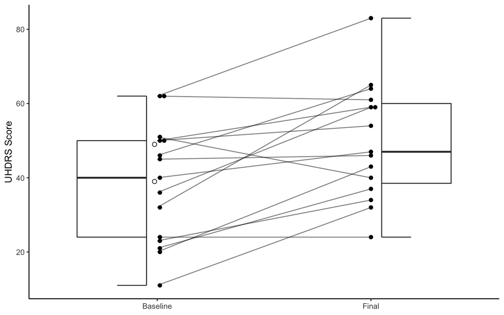

## 2.4 Adverse events

### 2.4.1 Overall

| AE experienced | n | pct<sup>1</sup> |
| --- | --- | --- |
| Total | 26 | 100% |
| Akathisia | 5 | 19.2% |
| Insomnia | 5 | 19.2% |
| Anxiety | 3 | 11.5% |
| Drowsiness/sedation | 3 | 11.5% |
| Depression | 2 | 7.7% |
| Dizziness | 1 | 3.8% |
| Increased urination | 1 | 3.8% |
| Mental status changes | 1 | 3.8% |
| Pseudoparkinsonism | 1 | 3.8% |
| Sedation | 1 | 3.8% |
| Urinary tract infection | 1 | 3.8% |
| Vomiting | 1 | 3.8% |
| Worsened movements | 1 | 3.8% |

<sup>1</sup> Denominator = 26

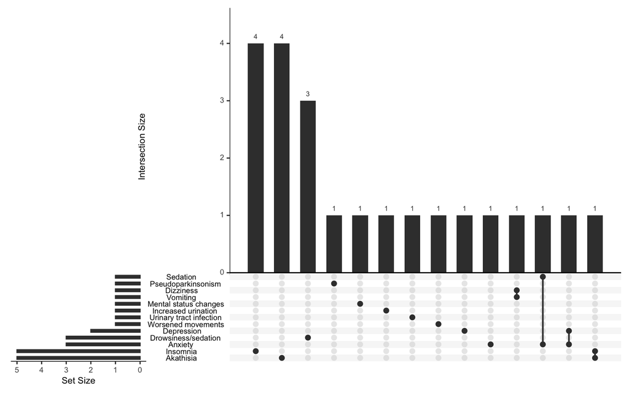

### 2.4.2 Record level

| **Characteristic** | **N** | **N = 22**<sup>1</sup> |
| --- | --- | --- |
| How were adverse effects identified? | 22 |  |
| Patient portal |  | 1 (4.55%) |
| Contact with clinic staff |  | 17 (77.3%) |
| Contact with specialty pharmacy staff |  | 4 (18.2%) |
| Other |  | 0 (0%) |

<sup>1</sup> n (%)

### 2.4.3 Timing of AEs

The following figure and table are tools to describe the timing of AEs in relation to dose changes. There are three people who had a dose change within 6 weeks of an AE: 3, 4, 5

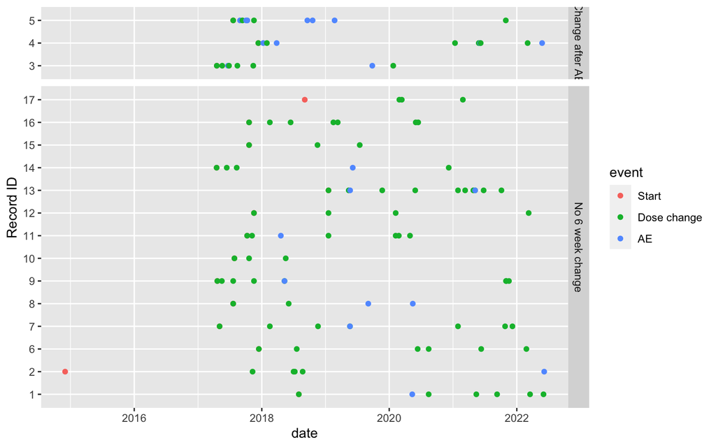

## 2.5 LFT

| **Characteristic** | **N** | **Repeated value** **1**, N = 10<sup>1</sup> | **Repeated value** **2**, N = 5<sup>1</sup> | **Repeated value** **3**, N = 3<sup>1</sup> | **Repeated value** **4**, N = 3<sup>1</sup> | **Repeated value** **5**, N = 1<sup>1</sup> | **Overall**, N = 22<sup>1</sup> |  |
| --- | --- | --- | --- | --- | --- | --- | --- | --- |
| Liver function testing | 22 |  |  |  |  |  |  |  |
| Within normal limits |  | 8 (80.0%) | 4 (80.0%) | 2 (66.7%) | 2 (66.7%) | 0 (0%) | 16 (72.7%) |  |
| Elevated |  | 2 (20.0%) | 1 (20.0%) | 1 (33.3%) | 1 (33.3%) | 1 (100.0%) | 6 (27.3%) |  |

<sup>1</sup> n (%)

## 2.6 EKG

| **Characteristic** | **N** | **Repeated value** **1**, N = 11<sup>1</sup> | **Repeated value** **2**, N = 8<sup>1</sup> | **Repeated value** **3**, N = 4<sup>1</sup> | **Repeated value** **4**, N = 2<sup>1</sup> | **Repeated value** **5**, N = 1<sup>1</sup> | **Overall**, N = 26<sup>1</sup> |  |
| --- | --- | --- | --- | --- | --- | --- | --- | --- |
| QT on Electrocardiogram | 26 |  |  |  |  |  |  |  |
| Within normal limits |  | 10 (90.9%) | 7 (87.5%) | 4 (100.0%) | 2 (100.0%) | 1 (100.0%) | 24 (92.3%) |  |
| Prolonged |  | 1 (9.09%) | 1 (12.5%) | 0 (0%) | 0 (0%) | 0 (0%) | 2 (7.69%) |  |
| Not completed |  | 0 (0%) | 0 (0%) | 0 (0%) | 0 (0%) | 0 (0%) | 0 (0%) |  |

<sup>1</sup> n (%)

| **Characteristic** | **N** | **N = 17**<sup>1</sup> |
| --- | --- | --- |
| n.ekg | 17 |  |
| 0 |  | 6 (35.3%) |
| 1 |  | 3 (17.6%) |
| 2 |  | 4 (23.5%) |
| 3 |  | 2 (11.8%) |
| 4 |  | 1 (5.88%) |
| 5 |  | 1 (5.88%) |
| n.prolonged | 17 |  |
| 0 |  | 15 (88.2%) |
| 1 |  | 2 (11.8%) |

<sup>1</sup> n (%)

## 2.7 Clinic Visit

| **Characteristic** | **N** | **N = 168**<sup>1</sup> |
| --- | --- | --- |
| Objective physical assessment measure at the time of prescribing | 168 |  |
| UHDRS |  | 126 (75.0%) |
| Other |  | 0 (0%) |
| None |  | 42 (25.0%) |
| Is the patient on other chorea treatment? | 168 |  |
| No |  | 39 (23.2%) |
| Yes |  | 129 (76.8%) |

<sup>1</sup> n (%)

## 2.8 Dose Change

| **Characteristic** | **N** | **N = 89**<sup>1</sup> |
| --- | --- | --- |
| Method of patient interaction when dose change occurred | 86 |  |
| Clinic visit |  | 56 (65.1%) |
| Communication with the pharmacist |  | 10 (11.6%) |
| Communication with the provider office |  | 15 (17.4%) |
| Other |  | 2 (2.33%) |
| Patient self-initiated |  | 2 (2.33%) |
| Hospital admission |  | 0 (0%) |
| Study visit |  | 1 (1.16%) |
| Missing |  | 3 |
| Deutetrabenazine dose change direction | 89 |  |
| Increase |  | 59 (66.3%) |
| Decrease |  | 6 (6.74%) |
| Discontinue |  | 6 (6.74%) |
| Initiate |  | 18 (20.2%) |
| Deutetrabenazine total daily dose at beginning of encounter | 89 |  |
| Mean (SD) |  | 39.9 (22.9) |
| Median (IQR) |  | 48.0 (30.0 - 60.0) |
| Range |  | 0.0 - 72.0 |
| Deutetrabenazine total daily dose at end of encounter | 89 |  |
| Mean (SD) |  | 49.3 (18.1) |
| Median (IQR) |  | 54.0 (42.0 - 60.0) |
| Range |  | 0.0 - 72.0 |
| Who communicated with patient and identified need for dose change? | 86 |  |
| Nursing staff |  | 2 (2.33%) |
| Pharmacist |  | 10 (11.6%) |
| Provider |  | 71 (82.6%) |
| Other |  | 1 (1.16%) |
| Patient self-initiated |  | 2 (2.33%) |
| Missing |  | 3 |

<sup>1</sup> n (%)